```python
# Ignore this code; it's only here to display the image below
%matplotlib inline
from IPython.display import Image
Image("../images/logo.jpg")
```

[output not shown]

# Python for scientific research

# Data analysis with `Pandas`

### University of Exeter, Penryn Campus, UK

### June 2017

# Introduction

`Pandas` is Python's data analysis toolkit, used for:

- Reading/writing data of different formats (e.g CSV, SQL database)
- Creating and manipulating data frames (akin to R)
- Handling missing data
- Meging/joining data sets
- Reshaping/pivoting data sets
- Time-series analysis
- $\ldots$

A very useful `Pandas` cheat sheet can be found [here](https://github.com/pandas-dev/pandas/blob/master/doc/cheatsheet/Pandas_Cheat_Sheet.pdf)

# Creating a data frame

This can be created by specifying a dictionary where each entry corresponds to a column in the dataset. In this case let us consider collecting data from various individuals (samples) at times t0, t1,...,t5

```python
import pandas as pd

df = pd.DataFrame(
        {"Sample" : ["R100" , "R201", "R203", "R340", "R453"],
         "t0" : [0.2, 0.1, 0.3, 0.25, 0.13],
         "t1" : [1.3, 1.8, 0.8, 1.5, 0.6],
         "t2" : [2.8, 3.1, 1.9, 2.3, 1.8],
         "t3" : [3.2, 3.7, 2.3, 3.5, 2.5],
         "t4" : [1.2, 1.8, 3.9, 1.3, 3.7],
         "t5" : [0.7, 0.4, 3.4, 0.3, 3.6]})
```

```python
type(df)
```

```
pandas.core.frame.DataFrame
```

```python
df
```

|  | Sample | t0 | t1 | t2 | t3 | t4 | t5 |
| --- | --- | --- | --- | --- | --- | --- | --- |
| 0 | R100 | 0.20 | 1.3 | 2.8 | 3.2 | 1.2 | 0.7 |
| 1 | R201 | 0.10 | 1.8 | 3.1 | 3.7 | 1.8 | 0.4 |
| 2 | R203 | 0.30 | 0.8 | 1.9 | 2.3 | 3.9 | 3.4 |
| 3 | R340 | 0.25 | 1.5 | 2.3 | 3.5 | 1.3 | 0.3 |
| 4 | R453 | 0.13 | 0.6 | 1.8 | 2.5 | 3.7 | 3.6 |

Let us look at a few operations that we can perform on an object of type `DataFrame`

```python
df.shape # returns (#rows, #columns)
```

```
(5, 7)
```

```python
df.columns # returns the names of columns
```

```
Index(['Sample', 't0', 't1', 't2', 't3', 't4', 't5'], dtype='object')
```

```python
df.index # returns the names of unique row indices
```

```
RangeIndex(start=0, stop=5, step=1)
```

```python
df["Sample"] # access all rows of column name "Sample"
```

```
0    R100
1    R201
2    R203
3    R340
4    R453
Name: Sample, dtype: object
```

```python
df["t2"] # access all rows of column name "t2"
```

```
0    2.8
1    3.1
2    1.9
3    2.3
4    1.8
Name: t2, dtype: float64
```

```python
df[["t2", "t4"]] # access all rows of columns name "t2" and "t4"
```

|  | t2 | t4 |
| --- | --- | --- |
| 0 | 2.8 | 1.2 |
| 1 | 3.1 | 1.8 |
| 2 | 1.9 | 3.9 |
| 3 | 2.3 | 1.3 |
| 4 | 1.8 | 3.7 |

```python
df["t2"].mean() # compute mean of column "t2"
```

```
2.3800000000000003
```

```python
df["t2"][:2] # access the first two rows of column name "t2"
```

```
0    2.8
1    3.1
Name: t2, dtype: float64
```

```python
df.iloc[:2] # select first two rows
```

|  | Sample | t0 | t1 | t2 | t3 | t4 | t5 |
| --- | --- | --- | --- | --- | --- | --- | --- |
| 0 | R100 | 0.2 | 1.3 | 2.8 | 3.2 | 1.2 | 0.7 |
| 1 | R201 | 0.1 | 1.8 | 3.1 | 3.7 | 1.8 | 0.4 |

```python
df.iloc[-2:] # select last two rows
```

|  | Sample | t0 | t1 | t2 | t3 | t4 | t5 |
| --- | --- | --- | --- | --- | --- | --- | --- |
| 3 | R340 | 0.25 | 1.5 | 2.3 | 3.5 | 1.3 | 0.3 |
| 4 | R453 | 0.13 | 0.6 | 1.8 | 2.5 | 3.7 | 3.6 |

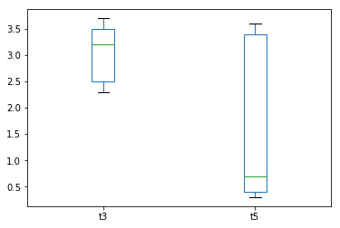

```python
df.plot(y = ["t3", "t5"], kind="box") # produce box plot of columns "t3" and "t5" (Note: y can only be a column name)
```

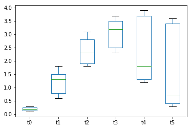

```python
df.plot(kind="box") # produce a boxplot of all numeric data columns
```

## Exercise 1

1. Create a `Pandas` data frame using a dictionary as shown above. For each column use the appropriate method to compute the min, max, mean and median.
2. Using the reshaping functions introduced in the lecture, reshape the data frame such that you can plot a time series for any individual of choice (as shown in lecture notes). Also produce a time-series plot with *all* individuals on it.

```python
df.min()
```

```
Sample    R100
t0         0.1
t1         0.6
t2         1.8
t3         2.3
t4         1.2
t5         0.3
dtype: object
```

# Reading data files

`Pandas` offers a wide range of functions that supports reading/writing data of different formats (text file, spreadsheet, database etc.). Here we will focus on simple text files. Let's use the generic `read_table()` function to read the data file `births_per_woman.csv`.

```python
# Note: On Windows machines you have to change the file separator "/" to "\"
data = pd.read_table("../data/births_per_woman.csv", header=0, sep=",")
```

```python
data.head()
```

|  | CountryName | Region | IncomeGroup | 1960 | 1961 | 1962 | 1963 | 1964 | 1965 | 1966 | ... | 2006 | 2007 | 2008 | 2009 | 2010 | 2011 | 2012 | 2013 | 2014 | 2015 |
| --- | --- | --- | --- | --- | --- | --- | --- | --- | --- | --- | --- | --- | --- | --- | --- | --- | --- | --- | --- | --- | --- |
| 0 | Aruba | Latin America & Caribbean | High income | 4.820 | 4.655 | 4.471 | 4.271 | 4.059 | 3.842 | 3.625 | ... | 1.754 | 1.741 | 1.728 | 1.716 | 1.704 | 1.692 | 1.680 | 1.669 | 1.657 | 1.647 |
| 1 | Afghanistan | South Asia | Low income | 7.450 | 7.450 | 7.450 | 7.450 | 7.450 | 7.450 | 7.450 | ... | 6.639 | 6.437 | 6.218 | 5.985 | 5.746 | 5.506 | 5.272 | 5.050 | 4.843 | 4.653 |
| 2 | Angola | Sub-Saharan Africa | Upper middle income | 7.379 | 7.388 | 7.396 | 7.402 | 7.406 | 7.408 | 7.406 | ... | 6.671 | 6.619 | 6.559 | 6.492 | 6.416 | 6.335 | 6.251 | 6.165 | 6.080 | 5.996 |
| 3 | Albania | Europe & Central Asia | Upper middle income | 6.489 | 6.401 | 6.282 | 6.133 | 5.960 | 5.773 | 5.581 | ... | 1.668 | 1.635 | 1.625 | 1.636 | 1.663 | 1.699 | 1.735 | 1.765 | 1.784 | 1.793 |
| 4 | Andorra | Europe & Central Asia | High income | NaN | NaN | NaN | NaN | NaN | NaN | NaN | ... | 1.240 | 1.180 | 1.250 | 1.190 | 1.270 | NaN | NaN | NaN | NaN | NaN |

5 rows × 59 columns

# Exercise 2

1. What was the mean and median birth rate in 1975, 1985, 1995, 2005 and 2015?
2. Which country had consistently the highest births per woman between 1990 and 1996 inclusive?
3. Using the reshaping functions introduced in the lecture notes, reshape the data such that you can plot births per woman over time for Kenya, Uganda, Niger and Botswana (on one plot).

**Hint 1**: Recall that multiple columns can be accessed using a list e.g `data[["1975", "1985", "1995", "2005", "2015"]].median()`

**Hint 2**: The `.idxmax()` method returns the row number of where the maximum occurs